[figure not shown]

## G2M Insight for Cab Investment Firm

# Problem Statement

## Context:

XYZ is a private firm in US. Due to remarkable growth in the Cab Industry in last few years and multiple key players in the market, it is planning for an investment in Cab industry and as per their Go-to-Market(G2M) strategy they want to understand the market before taking final decision.

## Objective:

You have been provided with multiple data sets that contains information on 2 cab companies. Each file (data set) provided represents different aspects of the customer profile. XYZ is interested in using your actionable insights to help them identify the right company to make their investment.

The outcome of your delivery will be a presentation to XYZ’s Executive team. This presentation will be judged based on the visuals provided, the quality of your analysis and the value of your recommendations and insights.

## Data Description:

Time period of data is from 31/01/2016 to 31/12/2018.

Below are the list of datasets which are provided for the analysis:

Cab_Data.csv – this file includes details of transaction for 2 cab companies

Customer_ID.csv – this is a mapping table that contains a unique identifier which links the customer’s demographic details

Transaction_ID.csv – this is a mapping table that contains transaction to customer mapping and payment mode

City.csv – this file contains list of US cities, their population and number of cab users

You should fully investigate and understand each data set.

- Review the Source Documentation
- Understand the field names and data types
- Identify relationships across the files
- Field/feature transformations
- Determine which files should be joined versus which ones should be appended
- Create master data and explain the relationship
- Identify and remove duplicates
- Perform other analysis like NA value and outlier detection

# Importing necessary libraries

```python
# To help with reading and manipulating data
import pandas as pd
import numpy as np

#To convert to datetime
from datetime import datetime, timedelta

# To help with data visualization
%matplotlib inline
import matplotlib.pyplot as plt
import seaborn as sns

# setting the precision of floating numbers to 2 decimal points
pd.set_option("display.float_format", lambda x: "%.2f" % x)

# To supress warnings
import warnings

warnings.filterwarnings("ignore")
from statsmodels.tools.sm_exceptions import ConvergenceWarning

warnings.simplefilter("ignore", ConvergenceWarning)
```

# Loading the datasets

```python
# loading the dataset from my local folder
cab_data = pd.read_csv(r"C:\Users\Mr Abiona\Documents\DSBA UT\Data Glacier\G2M insight for Cab Investment firm\DataSets-main\Cab_Data.csv")
```

```python
# creating a copy of the dataset
df_cab = cab_data.copy()
df_cab.head(3)
```

|  | Transaction ID | Date of Travel | Company | City | KM Travelled | Price Charged | Cost of Trip |
| --- | --- | --- | --- | --- | --- | --- | --- |
| 0 | 10000011 | 42377 | Pink Cab | ATLANTA GA | 30.45 | 370.95 | 313.63 |
| 1 | 10000012 | 42375 | Pink Cab | ATLANTA GA | 28.62 | 358.52 | 334.85 |
| 2 | 10000013 | 42371 | Pink Cab | ATLANTA GA | 9.04 | 125.20 | 97.63 |

```python
# checking the shape of the dataset
df_cab.shape
```

```
(359392, 7)
```

```python
# loading the dataset from my local folder
city_data = pd.read_csv(r"C:\Users\Mr Abiona\Documents\DSBA UT\Data Glacier\G2M insight for Cab Investment firm\DataSets-main\City.csv")
```

```python
# creating a copy of the dataset
df_city = city_data.copy()
df_city.head(3)
```

|  | City | Population | Users |
| --- | --- | --- | --- |
| 0 | NEW YORK NY | 8,405,837 | 302,149 |
| 1 | CHICAGO IL | 1,955,130 | 164,468 |
| 2 | LOS ANGELES CA | 1,595,037 | 144,132 |

```python
# checking the shape of the dataset
df_city.shape
```

```
(20, 3)
```

```python
# loading and creating a copy of the dataset
Cust_id_data = pd.read_csv(r"C:\Users\Mr Abiona\Documents\DSBA UT\Data Glacier\G2M insight for Cab Investment firm\DataSets-main\Customer_ID.csv")

df_cust = Cust_id_data.copy()
df_cust.head(3)
```

|  | Customer ID | Gender | Age | Income (USD/Month) |
| --- | --- | --- | --- | --- |
| 0 | 29290 | Male | 28 | 10813 |
| 1 | 27703 | Male | 27 | 9237 |
| 2 | 28712 | Male | 53 | 11242 |

```python
# checking the shape of the dataset
df_cust.shape
```

```
(49171, 4)
```

```python
# loading and creating a copy of the dataset
trans_id_data = pd.read_csv(r"C:\Users\Mr Abiona\Documents\DSBA UT\Data Glacier\G2M insight for Cab Investment firm\DataSets-main\Transaction_ID.csv")

df_trans = trans_id_data.copy()
df_trans.head(3)
```

|  | Transaction ID | Customer ID | Payment_Mode |
| --- | --- | --- | --- |
| 0 | 10000011 | 29290 | Card |
| 1 | 10000012 | 27703 | Card |
| 2 | 10000013 | 28712 | Cash |

```python
# checking the shape of the dataset
df_trans.shape
```

```
(440098, 3)
```

## Merging the datasets into one

```python
# merging df_cab and df_city datasets
cabcity_data = pd.merge(left = df_cab, right = df_city, how = "inner")
cabcity_data.head(3)
```

|  | Transaction ID | Date of Travel | Company | City | KM Travelled | Price Charged | Cost of Trip | Population | Users |
| --- | --- | --- | --- | --- | --- | --- | --- | --- | --- |
| 0 | 10000011 | 42377 | Pink Cab | ATLANTA GA | 30.45 | 370.95 | 313.63 | 814,885 | 24,701 |
| 1 | 10000012 | 42375 | Pink Cab | ATLANTA GA | 28.62 | 358.52 | 334.85 | 814,885 | 24,701 |
| 2 | 10000013 | 42371 | Pink Cab | ATLANTA GA | 9.04 | 125.20 | 97.63 | 814,885 | 24,701 |

```python
# Checking the number of Cities in df_City
df_city.City.value_counts()
```

```
NEW YORK NY         1
CHICAGO IL          1
NASHVILLE TN        1
WASHINGTON DC       1
PITTSBURGH PA       1
SACRAMENTO CA       1
SAN FRANCISCO CA    1
TUCSON AZ           1
SEATTLE WA          1
AUSTIN TX           1
DENVER CO           1
ATLANTA GA          1
DALLAS TX           1
PHOENIX AZ          1
SAN DIEGO CA        1
ORANGE COUNTY       1
SILICON VALLEY      1
MIAMI FL            1
LOS ANGELES CA      1
BOSTON MA           1
Name: City, dtype: int64
```

```python
df_cab.City.value_counts()
```

```
NEW YORK NY       99885
CHICAGO IL        56625
LOS ANGELES CA    48033
WASHINGTON DC     43737
BOSTON MA         29692
SAN DIEGO CA      20488
SILICON VALLEY     8519
SEATTLE WA         7997
ATLANTA GA         7557
DALLAS TX          7017
MIAMI FL           6454
AUSTIN TX          4896
ORANGE COUNTY      3982
DENVER CO          3825
NASHVILLE TN       3010
SACRAMENTO CA      2367
PHOENIX AZ         2064
TUCSON AZ          1931
PITTSBURGH PA      1313
Name: City, dtype: int64
```

```python
# Checking the number of Cities in merged dataframe
cabcity_data.City.value_counts()
```

```
NEW YORK NY       99885
CHICAGO IL        56625
LOS ANGELES CA    48033
WASHINGTON DC     43737
BOSTON MA         29692
SAN DIEGO CA      20488
SILICON VALLEY     8519
SEATTLE WA         7997
ATLANTA GA         7557
DALLAS TX          7017
MIAMI FL           6454
AUSTIN TX          4896
ORANGE COUNTY      3982
DENVER CO          3825
NASHVILLE TN       3010
SACRAMENTO CA      2367
PHOENIX AZ         2064
TUCSON AZ          1931
PITTSBURGH PA      1313
Name: City, dtype: int64
```

```python
# checking the shape of the dataset
cabcity_data.shape
```

```
(359392, 9)
```

#### Observation:

- There appears to be no cab data for San Francisco otherwise the number of observations is maintained.

```python
# merging df_trans and df_cust datasets
cust_trans_data = pd.merge(left = df_trans, right = df_cust, how = "inner")
cust_trans_data.head(3)
```

|  | Transaction ID | Customer ID | Payment_Mode | Gender | Age | Income (USD/Month) |
| --- | --- | --- | --- | --- | --- | --- |
| 0 | 10000011 | 29290 | Card | Male | 28 | 10813 |
| 1 | 10351127 | 29290 | Cash | Male | 28 | 10813 |
| 2 | 10412921 | 29290 | Card | Male | 28 | 10813 |

```python
# checking the shape of the dataset
cust_trans_data.shape
```

```
(440098, 6)
```

#### Observation:

- The number of observations is maintained

```python
# Joining of  cabcity_data with cust_trans_data dataset
full_cabdata = pd.merge(left = cabcity_data, right = cust_trans_data, how = "inner")
full_cabdata.head()
```

|  | Transaction ID | Date of Travel | Company | City | KM Travelled | Price Charged | Cost of Trip | Population | Users | Customer ID | Payment_Mode | Gender | Age | Income (USD/Month) |
| --- | --- | --- | --- | --- | --- | --- | --- | --- | --- | --- | --- | --- | --- | --- |
| 0 | 10000011 | 42377 | Pink Cab | ATLANTA GA | 30.45 | 370.95 | 313.63 | 814,885 | 24,701 | 29290 | Card | Male | 28 | 10813 |
| 1 | 10000012 | 42375 | Pink Cab | ATLANTA GA | 28.62 | 358.52 | 334.85 | 814,885 | 24,701 | 27703 | Card | Male | 27 | 9237 |
| 2 | 10000013 | 42371 | Pink Cab | ATLANTA GA | 9.04 | 125.20 | 97.63 | 814,885 | 24,701 | 28712 | Cash | Male | 53 | 11242 |
| 3 | 10000014 | 42376 | Pink Cab | ATLANTA GA | 33.17 | 377.40 | 351.60 | 814,885 | 24,701 | 28020 | Cash | Male | 23 | 23327 |
| 4 | 10000015 | 42372 | Pink Cab | ATLANTA GA | 8.73 | 114.62 | 97.78 | 814,885 | 24,701 | 27182 | Card | Male | 33 | 8536 |

```python
# checking the shape of the dataset
full_cabdata.shape
```

```
(359392, 14)
```

#### Observations:

- The number of observations is consistent with the number of observations in the `df_cab`.
- Observations (80,706 of 440,098) in `df_trans` that do not have corresponding data with `df_cab` have been removed.

```python
# creating a copy of the merged dataset
dff = full_cabdata.copy()
dff.head(3)
```

|  | Transaction ID | Date of Travel | Company | City | KM Travelled | Price Charged | Cost of Trip | Population | Users | Customer ID | Payment_Mode | Gender | Age | Income (USD/Month) |
| --- | --- | --- | --- | --- | --- | --- | --- | --- | --- | --- | --- | --- | --- | --- |
| 0 | 10000011 | 42377 | Pink Cab | ATLANTA GA | 30.45 | 370.95 | 313.63 | 814,885 | 24,701 | 29290 | Card | Male | 28 | 10813 |
| 1 | 10000012 | 42375 | Pink Cab | ATLANTA GA | 28.62 | 358.52 | 334.85 | 814,885 | 24,701 | 27703 | Card | Male | 27 | 9237 |
| 2 | 10000013 | 42371 | Pink Cab | ATLANTA GA | 9.04 | 125.20 | 97.63 | 814,885 | 24,701 | 28712 | Cash | Male | 53 | 11242 |

```python
dff.shape
```

```
(359392, 14)
```

#### Observations:

- The dataset has 359,392 observations and 14 features

```python
# Date Initialization to convert timedelta
start_date = datetime(1900, 1, 1)

# Converting the 'Date of Travel' column from timedelta to conventional date format
index = range(dff['Date of Travel'].count())
for i in index:
    dff['Date of Travel'][i] = (start_date + timedelta(days=int(dff['Date of Travel'][i])-2)).strftime("%d/%m/%Y")

dff.head(3)
```

|  | Transaction ID | Date of Travel | Company | City | KM Travelled | Price Charged | Cost of Trip | Population | Users | Customer ID | Payment_Mode | Gender | Age | Income (USD/Month) |
| --- | --- | --- | --- | --- | --- | --- | --- | --- | --- | --- | --- | --- | --- | --- |
| 0 | 10000011 | 08/01/2016 | Pink Cab | ATLANTA GA | 30.45 | 370.95 | 313.63 | 814,885 | 24,701 | 29290 | Card | Male | 28 | 10813 |
| 1 | 10000012 | 06/01/2016 | Pink Cab | ATLANTA GA | 28.62 | 358.52 | 334.85 | 814,885 | 24,701 | 27703 | Card | Male | 27 | 9237 |
| 2 | 10000013 | 02/01/2016 | Pink Cab | ATLANTA GA | 9.04 | 125.20 | 97.63 | 814,885 | 24,701 | 28712 | Cash | Male | 53 | 11242 |

```python
# To change the data type of the'Date of Travel' column to datetime data type
dff['Date of Travel'] = pd.to_datetime(dff['Date of Travel'], format='%d/%m/%Y')
dff.info()
```

```
<class 'pandas.core.frame.DataFrame'>
Int64Index: 359392 entries, 0 to 359391
Data columns (total 14 columns):
 #   Column              Non-Null Count   Dtype
---  ------              --------------   -----
 0   Transaction ID      359392 non-null  int64
 1   Date of Travel      359392 non-null  datetime64[ns]
 2   Company             359392 non-null  object
 3   City                359392 non-null  object
 4   KM Travelled        359392 non-null  float64
 5   Price Charged       359392 non-null  float64
 6   Cost of Trip        359392 non-null  float64
 7   Population          359392 non-null  object
 8   Users               359392 non-null  object
 9   Customer ID         359392 non-null  int64
 10  Payment_Mode        359392 non-null  object
 11  Gender              359392 non-null  object
 12  Age                 359392 non-null  int64
 13  Income (USD/Month)  359392 non-null  int64
dtypes: datetime64[ns](1), float64(3), int64(4), object(6)
memory usage: 49.2+ MB
```

## Additional data

### US Holiday Data 2016 - 2018

```python
# loading and creating a copy of the holiday dataset
hol_data = pd.read_csv(r"C:\Users\Mr Abiona\Documents\DSBA UT\Data Glacier\G2M insight for Cab Investment firm\DataSets-main\us_states_hol_data.csv")

df_hol = hol_data.copy()
df_hol.head(3)
```

|  | City | Date | Holiday |
| --- | --- | --- | --- |
| 0 | NASHVILLE TN | 42370 | New Year's Day |
| 1 | NASHVILLE TN | 42387 | Martin Luther King Jr. Day |
| 2 | NASHVILLE TN | 42415 | President's Day |

```python
df_hol.shape
```

```
(817, 3)
```

```python
# Converting the 'Date' column from timedelta to conventional date format
index = range(df_hol['Date'].count())
for i in index:
    df_hol['Date'][i] = (start_date + timedelta(days=int(df_hol['Date'][i])-2)).strftime("%d/%m/%Y")

df_hol.head()
```

|  | City | Date | Holiday |
| --- | --- | --- | --- |
| 0 | NASHVILLE TN | 01/01/2016 | New Year's Day |
| 1 | NASHVILLE TN | 18/01/2016 | Martin Luther King Jr. Day |
| 2 | NASHVILLE TN | 15/02/2016 | President's Day |
| 3 | NASHVILLE TN | 25/03/2016 | Good Friday |
| 4 | NASHVILLE TN | 30/05/2016 | Memorial Day |

```python
# To change the data type of the'Date' column to datetime data type
df_hol['Date'] = pd.to_datetime(df_hol['Date'], format='%d/%m/%Y')
df_hol.info()
```

```
<class 'pandas.core.frame.DataFrame'>
RangeIndex: 817 entries, 0 to 816
Data columns (total 3 columns):
 #   Column   Non-Null Count  Dtype
---  ------   --------------  -----
 0   City     817 non-null    object
 1   Date     817 non-null    datetime64[ns]
 2   Holiday  817 non-null    object
dtypes: datetime64[ns](1), object(2)
memory usage: 19.3+ KB
```

#### Observation:

- The values in each coloumn are of the appropriate datatype

```python
# To check the name of the cities
df_hol.City.value_counts()
```

```
CHICAGO IL        50
NEW YORK NY       47
PITTSBURGH PA     47
BOSTON MA         45
ATLANTA GA        43
NASHVILLE TN      42
WASHINGTON DC     42
LOS ANGELES CA    42
AUSTIN TX         42
DENVER CO         42
PHOENIX AZ        42
SAN DIEGO CA      42
DALLAS TX         42
SACRAMENTO CA     42
MIAMI FL          42
TUCSON AZ         42
SILICON VALLEY    42
ORANGE COUNTY     42
SEATTLE WA        39
Name: City, dtype: int64
```

#### Observations:

- Name of cities is similar to that used in other relevarelevant dataframes
- Holiday dataframe ready for merging

### US Weather Data 2016 - 2018

```python
# loading and creating a copy of the weather dataset
weather_data = pd.read_csv(r"C:\Users\Mr Abiona\Documents\DSBA UT\Data Glacier\G2M insight for Cab Investment firm\DataSets-main\Weather_Data2.csv")

df_weather = weather_data.copy()
df_weather.head(3)
```

|  | name | datetime | tempmax | tempmin | temp | feelslikemax | feelslikemin | feelslike | dew | humidity | ... | solarenergy | uvindex | severerisk | sunrise | sunset | moonphase | conditions | description | icon | stations |
| --- | --- | --- | --- | --- | --- | --- | --- | --- | --- | --- | --- | --- | --- | --- | --- | --- | --- | --- | --- | --- | --- |
| 0 | NASHVILLE | 42370 | 6.50 | -0.10 | 2.20 | 5.50 | -2.60 | 0.60 | -4.10 | 64.10 | ... | 6.70 | 4 | NaN | 2016-01-01T06:58:12 | 2016-01-01T16:42:59 | 0.75 | Partially cloudy | Partly cloudy throughout the day. | partly-cloudy-day | 72327013897,KBNA,KMQY,72327313827,72327199999 |
| 1 | NASHVILLE | 42371 | 9.70 | -4.60 | 2.30 | 8.70 | -7.20 | 1.70 | -5.40 | 61.60 | ... | 12.50 | 6 | NaN | 2016-01-02T06:58:22 | 2016-01-02T16:43:46 | 0.77 | Clear | Clear conditions throughout the day. | clear-day | 72327013897,KBNA,KMQY,72327313827,72327199999 |
| 2 | NASHVILLE | 42372 | 11.50 | -1.60 | 3.70 | 11.50 | -4.10 | 2.50 | -4.10 | 59.90 | ... | 12.00 | 6 | NaN | 2016-01-03T06:58:30 | 2016-01-03T16:44:34 | 0.80 | Partially cloudy | Partly cloudy throughout the day. | partly-cloudy-day | 72327013897,KBNA,KMQY,72327313827,72327199999 |

3 rows × 33 columns

```python
# Listing the column names
df_weather.columns
```

```
Index(['name', 'datetime', 'tempmax', 'tempmin', 'temp', 'feelslikemax',
       'feelslikemin', 'feelslike', 'dew', 'humidity', 'precip', 'precipprob',
       'precipcover', 'preciptype', 'snow', 'snowdepth', 'windgust',
       'windspeed', 'winddir', 'sealevelpressure', 'cloudcover', 'visibility',
       'solarradiation', 'solarenergy', 'uvindex', 'severerisk', 'sunrise',
       'sunset', 'moonphase', 'conditions', 'description', 'icon', 'stations'],
      dtype='object')
```

```python
# Checking column values
df_weather.conditions.value_counts()
```

```
Partially cloudy                8683
Rain, Partially cloudy          5332
Clear                           4357
Rain, Overcast                  1211
Rain                             361
Overcast                         357
Snow, Rain, Partially cloudy     249
Snow, Rain, Overcast             138
Snow, Partially cloudy            77
Snow, Overcast                    31
Snow, Rain                        21
Snow                               7
Name: conditions, dtype: int64
```

```python
# Checking column values
df_weather.icon.value_counts()
```

```
partly-cloudy-day    8620
rain                 7214
clear-day            4347
cloudy                356
snow                  265
wind                   22
Name: icon, dtype: int64
```

```python
# Checking column values
df_weather.description.value_counts()
```

```
Partly cloudy throughout the day.                                            7072
Clear conditions throughout the day.                                         4339
Partly cloudy throughout the day with rain.                                  1354
Clearing in the afternoon.                                                   1134
Partly cloudy throughout the day with late afternoon rain.                    793
                                                                             ...
Clear conditions throughout the day with early morning snow.                    1
Clearing in the afternoon with rain or snow.                                    1
Clearing in the afternoon with early morning snow.                              1
Clearing in the afternoon with rain or snow in the morning and afternoon.       1
Clearing in the afternoon with rain or snow clearing later.                     1
Name: description, Length: 105, dtype: int64
```

```python
# Dropping columns with information unnecessary for this analysis
df_w = df_weather.drop(columns=['tempmax', 'tempmin', 'temp', 'feelslikemax',
       'feelslikemin', 'feelslike', 'dew', 'humidity', 'precip', 'precipprob',
       'precipcover', 'preciptype', 'snow', 'snowdepth', 'windgust',
       'windspeed', 'winddir', 'sealevelpressure', 'cloudcover', 'visibility',
       'solarradiation', 'solarenergy', 'uvindex', 'severerisk', 'sunrise',
       'sunset', 'moonphase', 'stations', 'conditions', 'description'])
```

```python
# Checking dataset head
df_w.head()
```

|  | name | datetime | icon |
| --- | --- | --- | --- |
| 0 | NASHVILLE | 42370 | partly-cloudy-day |
| 1 | NASHVILLE | 42371 | clear-day |
| 2 | NASHVILLE | 42372 | partly-cloudy-day |
| 3 | NASHVILLE | 42373 | partly-cloudy-day |
| 4 | NASHVILLE | 42374 | partly-cloudy-day |

```python
# Converting the 'datetime' column from timedelta to conventional date format
index = range(df_w['datetime'].count())
for i in index:
    df_w['datetime'][i] = (start_date + timedelta(days=int(df_w['datetime'][i])-2)).strftime("%d/%m/%Y")

df_w.head()
```

|  | name | datetime | icon |
| --- | --- | --- | --- |
| 0 | NASHVILLE | 01/01/2016 | partly-cloudy-day |
| 1 | NASHVILLE | 02/01/2016 | clear-day |
| 2 | NASHVILLE | 03/01/2016 | partly-cloudy-day |
| 3 | NASHVILLE | 04/01/2016 | partly-cloudy-day |
| 4 | NASHVILLE | 05/01/2016 | partly-cloudy-day |

```python
# To change the data type of the'datetime' column to datetime data type
df_w['datetime'] = pd.to_datetime(df_w['datetime'], format='%d/%m/%Y')
df_w.info()
```

```
<class 'pandas.core.frame.DataFrame'>
RangeIndex: 20824 entries, 0 to 20823
Data columns (total 3 columns):
 #   Column    Non-Null Count  Dtype
---  ------    --------------  -----
 0   name      20824 non-null  object
 1   datetime  20824 non-null  datetime64[ns]
 2   icon      20824 non-null  object
dtypes: datetime64[ns](1), object(2)
memory usage: 488.2+ KB
```

#### Observation:

- All columns are of the appropriate data type

```python
# Listing the name of cities in the weather data in preparation to
city_names = df_w.name.unique()
city_names.sort()
city_names
```

```
array(['ATLANTA', 'AUSTIN', 'BOSTON', 'CHICAGO', 'DALLAS', 'DENVER',
       'LOS ANGELES', 'MIAMI', 'NASHVILLE', 'NEW YORK', 'ORANGE COUNTY',
       'PHOENIX', 'PITTSBURGH', 'SACRAMENTO', 'SAN DIEGO', 'SEATTLE',
       'SILICON VALLEY', 'TUCSON', 'WASHINGTON DC'], dtype=object)
```

```python
# Checking the count for each city in the dataframe before name change
df_w.name.value_counts()
```

```
NASHVILLE         1096
PHOENIX           1096
ATLANTA           1096
BOSTON            1096
ORANGE COUNTY     1096
MIAMI             1096
SACRAMENTO        1096
DALLAS            1096
SAN DIEGO         1096
DENVER            1096
CHICAGO           1096
AUSTIN            1096
LOS ANGELES       1096
TUCSON            1096
SILICON VALLEY    1096
PITTSBURGH        1096
SEATTLE           1096
NEW YORK          1096
WASHINGTON DC     1096
Name: name, dtype: int64
```

```python
# Listing the name of cities in the dff data
citi_names = dff.City.unique()
citi_names.sort()
citi_names
```

```
array(['ATLANTA GA', 'AUSTIN TX', 'BOSTON MA', 'CHICAGO IL', 'DALLAS TX',
       'DENVER CO', 'LOS ANGELES CA', 'MIAMI FL', 'NASHVILLE TN',
       'NEW YORK NY', 'ORANGE COUNTY', 'PHOENIX AZ', 'PITTSBURGH PA',
       'SACRAMENTO CA', 'SAN DIEGO CA', 'SEATTLE WA', 'SILICON VALLEY',
       'TUCSON AZ', 'WASHINGTON DC'], dtype=object)
```

```python
# To change the name of each city to match that of other dataframes (dff and df_hol)
df_w['name'] = df_w['name'].replace(['ATLANTA', 'AUSTIN', 'BOSTON', 'CHICAGO', 'DALLAS', 'DENVER',
       'LOS ANGELES', 'MIAMI', 'NASHVILLE', 'NEW YORK', 'ORANGE COUNTY',
       'PHOENIX', 'PITTSBURGH', 'SACRAMENTO', 'SAN DIEGO', 'SEATTLE',
       'SILICON VALLEY', 'TUCSON', 'WASHINGTON'],['ATLANTA GA', 'AUSTIN TX', 'BOSTON MA', 'CHICAGO IL', 'DALLAS TX',
       'DENVER CO', 'LOS ANGELES CA', 'MIAMI FL', 'NASHVILLE TN',
       'NEW YORK NY', 'ORANGE COUNTY', 'PHOENIX AZ', 'PITTSBURGH PA',
       'SACRAMENTO CA', 'SAN DIEGO CA', 'SEATTLE WA', 'SILICON VALLEY',
       'TUCSON AZ', 'WASHINGTON DC'])

# Checking the count for each city in the dataframe after name change
df_w.name.value_counts()
```

```
NASHVILLE TN      1096
PHOENIX AZ        1096
ATLANTA GA        1096
BOSTON MA         1096
ORANGE COUNTY     1096
MIAMI FL          1096
SACRAMENTO CA     1096
DALLAS TX         1096
SAN DIEGO CA      1096
DENVER CO         1096
CHICAGO IL        1096
AUSTIN TX         1096
LOS ANGELES CA    1096
TUCSON AZ         1096
SILICON VALLEY    1096
PITTSBURGH PA     1096
SEATTLE WA        1096
NEW YORK NY       1096
WASHINGTON DC     1096
Name: name, dtype: int64
```

#### Observations:

- The name of the cities have been successfully changed to that of other relevant dataframes (dff and df_hol)
- Holiday dataframe ready for merging

## Checkpoint

```python
#creating copies as checkpoint for debug
df1 = dff.copy()
df1_w = df_w.copy()
df1_h = df_hol.copy()
```

## Joining the additional datasets

```python
# Checking column names
df1.head(1)
```

|  | Transaction ID | Date of Travel | Company | City | KM Travelled | Price Charged | Cost of Trip | Population | Users | Customer ID | Payment_Mode | Gender | Age | Income (USD/Month) |
| --- | --- | --- | --- | --- | --- | --- | --- | --- | --- | --- | --- | --- | --- | --- |
| 0 | 10000011 | 2016-01-08 | Pink Cab | ATLANTA GA | 30.45 | 370.95 | 313.63 | 814,885 | 24,701 | 29290 | Card | Male | 28 | 10813 |

#### Merging the weather data (df_w) to df1

```python
# Checkin column names
df1_w.head(1)
```

|  | name | datetime | icon |
| --- | --- | --- | --- |
| 0 | NASHVILLE TN | 2016-01-01 | partly-cloudy-day |

```python
#To rename the columns in the weather data for easy merging with fullcab (dff/df1)
df1_w.rename(columns={'name':'City', 'datetime':'Date of Travel', 'icon':'Icon'}, inplace=True)

# Checking column names
df1_w.head(1)
```

|  | City | Date of Travel | Icon |
| --- | --- | --- | --- |
| 0 | NASHVILLE TN | 2016-01-01 | partly-cloudy-day |

```python
#to merge fullcab (dff/df1) and weather data (df1_w)
merger = pd.merge(df1, df1_w, on =['City', 'Date of Travel'], how ='left')
#merger = pd.merge(left = df1, right = df1_w, on =['City', 'Date of Travel'], how = "left")

print(f'The shape of df is {dff.shape}')
print(f'The shape of the merged data is {merger.shape}')
```

```
The shape of df is (359392, 14)
The shape of the merged data is (359392, 15)
```

```python
merger.head()
```

|  | Transaction ID | Date of Travel | Company | City | KM Travelled | Price Charged | Cost of Trip | Population | Users | Customer ID | Payment_Mode | Gender | Age | Income (USD/Month) | Icon |
| --- | --- | --- | --- | --- | --- | --- | --- | --- | --- | --- | --- | --- | --- | --- | --- |
| 0 | 10000011 | 2016-01-08 | Pink Cab | ATLANTA GA | 30.45 | 370.95 | 313.63 | 814,885 | 24,701 | 29290 | Card | Male | 28 | 10813 | rain |
| 1 | 10000012 | 2016-01-06 | Pink Cab | ATLANTA GA | 28.62 | 358.52 | 334.85 | 814,885 | 24,701 | 27703 | Card | Male | 27 | 9237 | partly-cloudy-day |
| 2 | 10000013 | 2016-01-02 | Pink Cab | ATLANTA GA | 9.04 | 125.20 | 97.63 | 814,885 | 24,701 | 28712 | Cash | Male | 53 | 11242 | partly-cloudy-day |
| 3 | 10000014 | 2016-01-07 | Pink Cab | ATLANTA GA | 33.17 | 377.40 | 351.60 | 814,885 | 24,701 | 28020 | Cash | Male | 23 | 23327 | partly-cloudy-day |
| 4 | 10000015 | 2016-01-03 | Pink Cab | ATLANTA GA | 8.73 | 114.62 | 97.78 | 814,885 | 24,701 | 27182 | Card | Male | 33 | 8536 | partly-cloudy-day |

#### Observations:

- Merger successfully completed with no data loss

#### Merging the holiday data (df_hol) to merger dataframe

```python
# Checking column names
df1_h.head(1)
```

|  | City | Date | Holiday |
| --- | --- | --- | --- |
| 0 | NASHVILLE TN | 2016-01-01 | New Year's Day |

```python
#To rename the columns in the holiday data (df1_h) for easy merging with 'merger'
df1_h.rename(columns={'Date':'Date of Travel'}, inplace=True)

# Checking column names
df1_h.head(1)
```

|  | City | Date of Travel | Holiday |
| --- | --- | --- | --- |
| 0 | NASHVILLE TN | 2016-01-01 | New Year's Day |

```python
#to merge 'merger' and hol data (df1_h)
merger2 = pd.merge(merger, df1_h, on =['City', 'Date of Travel'], how ='left')

print(f'The shape of df is {dff.shape}')
print(f'The shape of the merged data is {merger2.shape}')
```

```
The shape of df is (359392, 14)
The shape of the merged data is (359592, 16)
```

```python
merger2.head(2)
```

|  | Transaction ID | Date of Travel | Company | City | KM Travelled | Price Charged | Cost of Trip | Population | Users | Customer ID | Payment_Mode | Gender | Age | Income (USD/Month) | Icon | Holiday |
| --- | --- | --- | --- | --- | --- | --- | --- | --- | --- | --- | --- | --- | --- | --- | --- | --- |
| 0 | 10000011 | 2016-01-08 | Pink Cab | ATLANTA GA | 30.45 | 370.95 | 313.63 | 814,885 | 24,701 | 29290 | Card | Male | 28 | 10813 | rain | NaN |
| 1 | 10000012 | 2016-01-06 | Pink Cab | ATLANTA GA | 28.62 | 358.52 | 334.85 | 814,885 | 24,701 | 27703 | Card | Male | 27 | 9237 | partly-cloudy-day | NaN |

#### Observations:

- Weather and Holiday data successfully merged with other dataframes
- There appears to be additional or duplicated observations as the number of observations have increased

## Checkpoint

```python
#Creating a checkpoint for debug
df = merger2.copy()
df.head(2)
```

|  | Transaction ID | Date of Travel | Company | City | KM Travelled | Price Charged | Cost of Trip | Population | Users | Customer ID | Payment_Mode | Gender | Age | Income (USD/Month) | Icon | Holiday |
| --- | --- | --- | --- | --- | --- | --- | --- | --- | --- | --- | --- | --- | --- | --- | --- | --- |
| 0 | 10000011 | 2016-01-08 | Pink Cab | ATLANTA GA | 30.45 | 370.95 | 313.63 | 814,885 | 24,701 | 29290 | Card | Male | 28 | 10813 | rain | NaN |
| 1 | 10000012 | 2016-01-06 | Pink Cab | ATLANTA GA | 28.62 | 358.52 | 334.85 | 814,885 | 24,701 | 27703 | Card | Male | 27 | 9237 | partly-cloudy-day | NaN |

# Data Overview

- Observations
- Sanity checks

```python
# Checking the shape of the dataset
df.shape
```

```
(359592, 16)
```

```python
# Checking the data types of the observations
df.info()
```

```
<class 'pandas.core.frame.DataFrame'>
Int64Index: 359592 entries, 0 to 359591
Data columns (total 16 columns):
 #   Column              Non-Null Count   Dtype
---  ------              --------------   -----
 0   Transaction ID      359592 non-null  int64
 1   Date of Travel      359592 non-null  datetime64[ns]
 2   Company             359592 non-null  object
 3   City                359592 non-null  object
 4   KM Travelled        359592 non-null  float64
 5   Price Charged       359592 non-null  float64
 6   Cost of Trip        359592 non-null  float64
 7   Population          359592 non-null  object
 8   Users               359592 non-null  object
 9   Customer ID         359592 non-null  int64
 10  Payment_Mode        359592 non-null  object
 11  Gender              359592 non-null  object
 12  Age                 359592 non-null  int64
 13  Income (USD/Month)  359592 non-null  int64
 14  Icon                359592 non-null  object
 15  Holiday             15380 non-null   object
dtypes: datetime64[ns](1), float64(3), int64(4), object(8)
memory usage: 46.6+ MB
```

#### Observations:

- There are 7 numerical features, 8 object features and 1 datetime feature
- `Population` and `Users` column are classified as object when they should be numerical
- `Holiday` coulumn has missing values which appear to correspond with days with no holidays

```python
# Checking for duplicated observations
df.duplicated().sum()
```

```
200
```

#### Observation:

- There are 200 duplicated observations

```python
# Checking for source of duplicates
dff.duplicated().sum()
```

```
0
```

```python
# Checking for source of duplicates
df1.duplicated().sum()
```

```
0
```

```python
# Checking for source of duplicates
merger.duplicated().sum()
```

```
0
```

```python
# Dropping duplicates
df.drop_duplicates(inplace=True)
print(df.duplicated().sum())
df.shape
```

```
0
```

```
(359392, 16)
```

#### Observations:

- There are no more duplicated observations

```python
# Checking for null entries
df.isnull().sum()
```

```
Transaction ID             0
Date of Travel             0
Company                    0
City                       0
KM Travelled               0
Price Charged              0
Cost of Trip               0
Population                 0
Users                      0
Customer ID                0
Payment_Mode               0
Gender                     0
Age                        0
Income (USD/Month)         0
Icon                       0
Holiday               344212
dtype: int64
```

#### Observations:

- `Holiday` column has null values due to non-holiday days

```python
df.Holiday.fillna('No Holiday', inplace=True)
```

```python
# Checking for null entries
df.isnull().sum()
```

```
Transaction ID        0
Date of Travel        0
Company               0
City                  0
KM Travelled          0
Price Charged         0
Cost of Trip          0
Population            0
Users                 0
Customer ID           0
Payment_Mode          0
Gender                0
Age                   0
Income (USD/Month)    0
Icon                  0
Holiday               0
dtype: int64
```

#### Observation:

- There are no more null values

```python
# Checking the values in the Population and Users columns
print(df['Population'].value_counts())
print('-' * 50)
df['Users'].value_counts()
```

```
 8,405,837     99885
 1,955,130     56625
 1,595,037     48033
 418,859       43737
 248,968       29692
 959,307       20488
 1,177,609      8519
 671,238        7997
 814,885        7557
 942,908        7017
 1,339,155      6454
 698,371        4896
 1,030,185      3982
 754,233        3825
 327,225        3010
 545,776        2367
 943,999        2064
 631,442        1931
 542,085        1313
Name: Population, dtype: int64
--------------------------------------------------
```

```
 302,149     99885
 164,468     56625
 144,132     48033
 127,001     43737
 80,021      29692
 69,995      20488
 27,247       8519
 25,063       7997
 24,701       7557
 22,157       7017
 17,675       6454
 14,978       4896
 12,994       3982
 12,421       3825
 9,270        3010
 7,044        2367
 6,133        2064
 5,712        1931
 3,643        1313
Name: Users, dtype: int64
```

#### Observations:

- Values in both columns are classified as object due to the use of commas. The commas will be removed

```python
# Removing the commas
df['Population'] = df['Population'].str.replace(',','')
df['Users'] = df['Users'].str.replace(',','')
```

```python
# Checking to see if commas have been removed
df.head(2)
```

|  | Transaction ID | Date of Travel | Company | City | KM Travelled | Price Charged | Cost of Trip | Population | Users | Customer ID | Payment_Mode | Gender | Age | Income (USD/Month) | Icon | Holiday |
| --- | --- | --- | --- | --- | --- | --- | --- | --- | --- | --- | --- | --- | --- | --- | --- | --- |
| 0 | 10000011 | 2016-01-08 | Pink Cab | ATLANTA GA | 30.45 | 370.95 | 313.63 | 814885 | 24701 | 29290 | Card | Male | 28 | 10813 | rain | No Holiday |
| 1 | 10000012 | 2016-01-06 | Pink Cab | ATLANTA GA | 28.62 | 358.52 | 334.85 | 814885 | 24701 | 27703 | Card | Male | 27 | 9237 | partly-cloudy-day | No Holiday |

```python
# Coverting the affected columns from object data type to Int data type
df['Population'] = df['Population'].astype(int)
df['Users'] = df['Users'].astype(int)
```

```python
# Checking that the data type changes have been effected
df.info()
```

```
<class 'pandas.core.frame.DataFrame'>
Int64Index: 359392 entries, 0 to 359591
Data columns (total 16 columns):
 #   Column              Non-Null Count   Dtype
---  ------              --------------   -----
 0   Transaction ID      359392 non-null  int64
 1   Date of Travel      359392 non-null  datetime64[ns]
 2   Company             359392 non-null  object
 3   City                359392 non-null  object
 4   KM Travelled        359392 non-null  float64
 5   Price Charged       359392 non-null  float64
 6   Cost of Trip        359392 non-null  float64
 7   Population          359392 non-null  int32
 8   Users               359392 non-null  int32
 9   Customer ID         359392 non-null  int64
 10  Payment_Mode        359392 non-null  object
 11  Gender              359392 non-null  object
 12  Age                 359392 non-null  int64
 13  Income (USD/Month)  359392 non-null  int64
 14  Icon                359392 non-null  object
 15  Holiday             359392 non-null  object
dtypes: datetime64[ns](1), float64(3), int32(2), int64(4), object(6)
memory usage: 43.9+ MB
```

#### Observations:

- The commas have been successfully removed
- The columns have been successfully converted to numeric data types

```python
# To check the statistical summaries of the features (numeric columns)
df.describe().T
```

|  | count | mean | std | min | 25% | 50% | 75% | max |
| --- | --- | --- | --- | --- | --- | --- | --- | --- |
| Transaction ID | 359392.00 | 10220761.19 | 126805.80 | 10000011.00 | 10110809.75 | 10221035.50 | 10330937.25 | 10440107.00 |
| KM Travelled | 359392.00 | 22.57 | 12.23 | 1.90 | 12.00 | 22.44 | 32.96 | 48.00 |
| Price Charged | 359392.00 | 423.44 | 274.38 | 15.60 | 206.44 | 386.36 | 583.66 | 2048.03 |
| Cost of Trip | 359392.00 | 286.19 | 157.99 | 19.00 | 151.20 | 282.48 | 413.68 | 691.20 |
| Population | 359392.00 | 3132198.04 | 3315194.39 | 248968.00 | 671238.00 | 1595037.00 | 8405837.00 | 8405837.00 |
| Users | 359392.00 | 158365.58 | 100850.05 | 3643.00 | 80021.00 | 144132.00 | 302149.00 | 302149.00 |
| Customer ID | 359392.00 | 19191.65 | 21012.41 | 1.00 | 2705.00 | 7459.00 | 36078.00 | 60000.00 |
| Age | 359392.00 | 35.34 | 12.59 | 18.00 | 25.00 | 33.00 | 42.00 | 65.00 |
| Income (USD/Month) | 359392.00 | 15048.82 | 7969.41 | 2000.00 | 8424.00 | 14685.00 | 21035.00 | 35000.00 |

#### Observations:

- `Transaction ID` and `Customer ID` are unique identifiers. Statistical analysis on these columns is not useful
- The average `KM Travelled` is 22.57km. 75% of tavels is at least 12km. The least traveled distance is 1.9 km while the most is 48 km
- The average `Price Charged` is 423.44. 50% of travel charges are between 206.44 and 583.66. The highest charge is 2048.03 while the least is 15.6
- The average `Cost of Trip` is 286.19. 50% of travel costs are between 151.20 and 413.68. The highest cost is 691.20 while the least is 19.00
- The least populated city has 248,968 people while the most has 8,405,837 people. The average population is 3,132,198
- The number of users range between 3,643 and 302,149 with the average being 158,365
- The average age of users is 35.34. The age range is between 18 and 65. 50% of users are 33 or younger
- The lowest income per month is 2000 USD while the highest is 35,000 USD. 75% of income is at least 8,424 USD or more. 50% of income is between 8,424 USD and 21,035 USD

```python
# To check the statistical summaries of the features (object columns)
df.describe(include="object").T
```

|  | count | unique | top | freq |
| --- | --- | --- | --- | --- |
| Company | 359392 | 2 | Yellow Cab | 274681 |
| City | 359392 | 19 | NEW YORK NY | 99885 |
| Payment_Mode | 359392 | 2 | Card | 215504 |
| Gender | 359392 | 2 | Male | 205912 |
| Icon | 359392 | 6 | rain | 147925 |
| Holiday | 359392 | 24 | No Holiday | 344212 |

## Exploratory Data Analysis (EDA)

```python
df.head()
```

|  | Transaction ID | Date of Travel | Company | City | KM Travelled | Price Charged | Cost of Trip | Population | Users | Customer ID | Payment_Mode | Gender | Age | Income (USD/Month) | Icon | Holiday |
| --- | --- | --- | --- | --- | --- | --- | --- | --- | --- | --- | --- | --- | --- | --- | --- | --- |
| 0 | 10000011 | 2016-01-08 | Pink Cab | ATLANTA GA | 30.45 | 370.95 | 313.63 | 814885 | 24701 | 29290 | Card | Male | 28 | 10813 | rain | No Holiday |
| 1 | 10000012 | 2016-01-06 | Pink Cab | ATLANTA GA | 28.62 | 358.52 | 334.85 | 814885 | 24701 | 27703 | Card | Male | 27 | 9237 | partly-cloudy-day | No Holiday |
| 2 | 10000013 | 2016-01-02 | Pink Cab | ATLANTA GA | 9.04 | 125.20 | 97.63 | 814885 | 24701 | 28712 | Cash | Male | 53 | 11242 | partly-cloudy-day | No Holiday |
| 3 | 10000014 | 2016-01-07 | Pink Cab | ATLANTA GA | 33.17 | 377.40 | 351.60 | 814885 | 24701 | 28020 | Cash | Male | 23 | 23327 | partly-cloudy-day | No Holiday |
| 4 | 10000015 | 2016-01-03 | Pink Cab | ATLANTA GA | 8.73 | 114.62 | 97.78 | 814885 | 24701 | 27182 | Card | Male | 33 | 8536 | partly-cloudy-day | No Holiday |

### Univariate Analysis

#### Date of Travel

```python
# Making a dataframe of month name and volume of transaction
month_df = pd.DataFrame({'month':df['Date of Travel'].dt.month_name().value_counts().index,
                         'no_of_trans':df['Date of Travel'].dt.month_name().value_counts().values,
                        '%age of trans':100*df['Date of Travel'].dt.month_name().value_counts(normalize=True).values})
month_df
```

|  | month | no_of_trans | %age of trans |
| --- | --- | --- | --- |
| 0 | December | 47007 | 13.08 |
| 1 | November | 42700 | 11.88 |
| 2 | October | 40852 | 11.37 |
| 3 | September | 36859 | 10.26 |
| 4 | August | 31323 | 8.72 |
| 5 | July | 27676 | 7.70 |
| 6 | June | 24713 | 6.88 |
| 7 | May | 23701 | 6.59 |
| 8 | January | 23174 | 6.45 |
| 9 | March | 21646 | 6.02 |
| 10 | April | 21434 | 5.96 |
| 11 | February | 18307 | 5.09 |

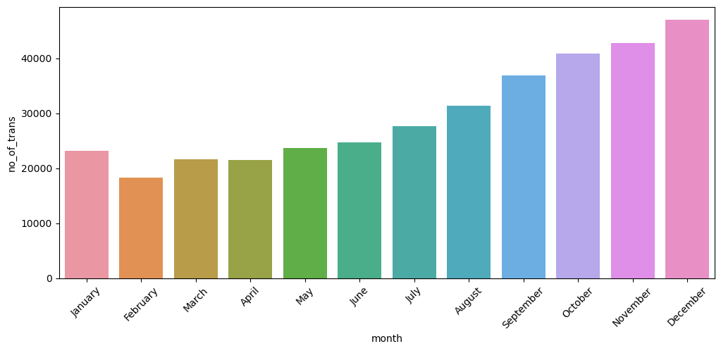

```python
# Making a plot of month vs volume of transaction from the dataframe
plt.figure(figsize=(12, 5))
sns.barplot(data=month_df, x='month', y='no_of_trans', order=['January', 'February', 'March',
                                                              'April', 'May', 'June', 'July',
                                                              'August', 'September', 'October',
                                                              'November', 'December'])
plt.xticks(rotation=45);
```

#### Observations:

- There is a general trend of volume of transactions gradually increasing each month as the year approaches `December`
- `January`, however, experiences higher transaction volume than `February` despite the sharp decline from `December`

#### Cab Company

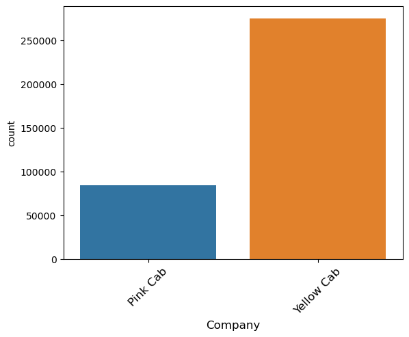

```python
sns.countplot(data=df, x='Company');
plt.xlabel('Company', fontsize=12);
plt.xticks(rotation=45, fontsize=12);
```

#### Observations:

- There are significantly more Yellow Cabs than Pink Cabs.
- This suggest that Yellow Cab is more active and common

#### City

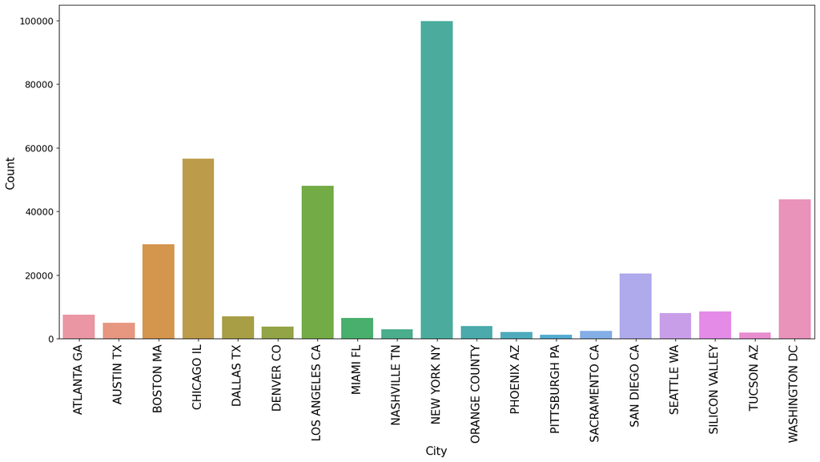

```python
plt.figure(figsize=(18, 8))
sns.countplot(data=df, x='City')
plt.ylabel('Count', fontsize=15)
plt.xlabel('City', fontsize=15)
plt.yticks(fontsize=12)
plt.xticks(rotation=90, fontsize=15)
plt.show();
```

```python
# To check the contribution of the top 5 cities
df.City.value_counts(normalize=True).head()
```

```
NEW YORK NY      0.28
CHICAGO IL       0.16
LOS ANGELES CA   0.13
WASHINGTON DC    0.12
BOSTON MA        0.08
Name: City, dtype: float64
```

#### Km Travelled

```
Observations:
 The median distance travelled is 22.44km
 75% of transactions cover at least 12.0km travel distance
 Most transactions do not go beyond 32.96km 75% of the time
```

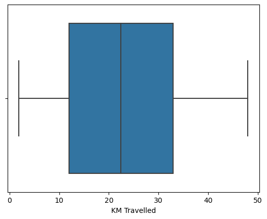

```python
sns.boxplot(data=df, x='KM Travelled');
print('Observations:')
print(f' The median distance travelled is {df["KM Travelled"].median()}km')
print(f' 75% of transactions cover at least {df["KM Travelled"].quantile(0.25)}km travel distance')
print(f' Most transactions do not go beyond {df["KM Travelled"].quantile(0.75)}km 75% of the time')
```

- The maximum distance covered is 48km while the minimum is 1.9km

#### Price Charged

```
Observations:
 The median price charged is 386.36 while the average is 423.44
 75% of transactions are charged at least 206.44
 Most transactions are not charged more than 583.66
```

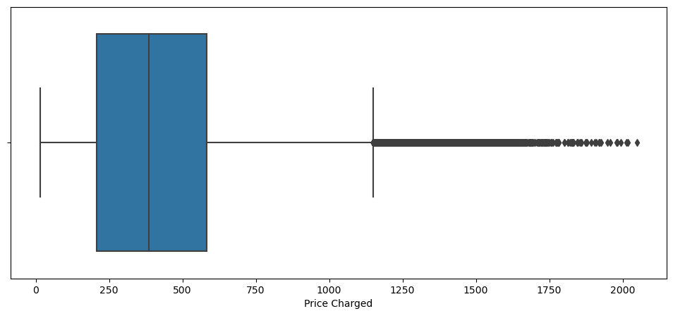

```python
plt.figure(figsize=(12, 5))
sns.boxplot(data=df, x='Price Charged');
print('Observations:')
print(f' The median price charged is {df["Price Charged"].median()} while the average is {round(df["Price Charged"].mean(),2)}')
print(f' 75% of transactions are charged at least {round(df["Price Charged"].quantile(0.25),2)}')
print(f' Most transactions are not charged more than {round(df["Price Charged"].quantile(0.75),2)}')
```

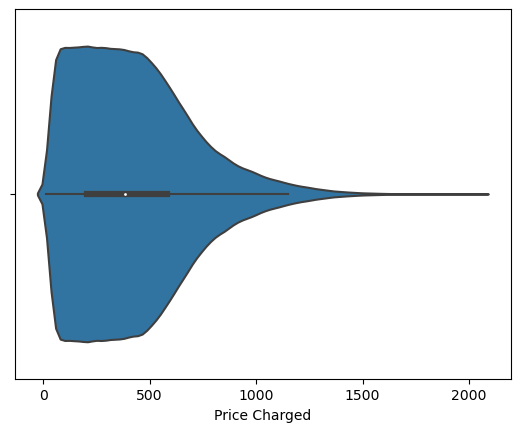

```python
# To check distribution of values
sns.violinplot(data=df, x='Price Charged');
```

More Observations:

- There are outlier prices from about 1,130
- Distribution of datapoints does not suggest there is need for outlier treatment.

#### Cost of Trip

```
Observations:
 The median cost of trip is 282.48 while the average is 286.19
 75% of transactions are cost at least 151.2
 Most transactions do not cost more than 413.68
```

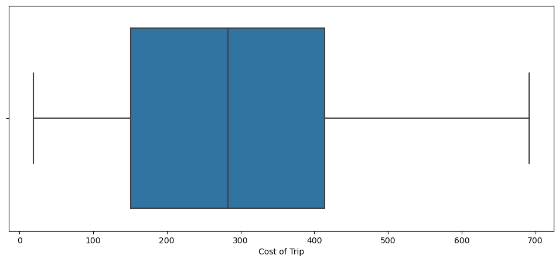

```python
plt.figure(figsize=(12, 5))
sns.boxplot(data=df, x='Cost of Trip');
print('Observations:')
print(f' The median cost of trip is {df["Cost of Trip"].median()} while the average is {round(df["Cost of Trip"].mean(),2)}')
print(f' 75% of transactions are cost at least {round(df["Cost of Trip"].quantile(0.25),2)}')
print(f' Most transactions do not cost more than {round(df["Cost of Trip"].quantile(0.75),2)}')
```

#### Population

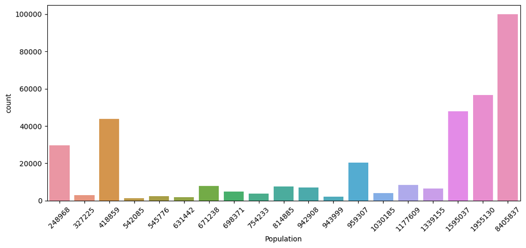

```python
#df['Population'] = np.where(np.isinf(df['Population']), np.nan, df['Population'])
plt.figure(figsize=(12, 5))
sns.countplot(df, x='Population')
plt.xticks(rotation=45);
```

#### Observation:

```python
# Age making a data of city population and volume of transaction
city_p = pd.DataFrame({'population':df.Population.value_counts(normalize=True).index,
                        'city':df.City.value_counts(normalize=True).index,
                         'no_of_trans':df.Population.value_counts().values,
                        '%age of trans':100*df.Population.value_counts(normalize=True).values})
city_p
```

|  | population | city | no_of_trans | %age of trans |
| --- | --- | --- | --- | --- |
| 0 | 8405837 | NEW YORK NY | 99885 | 27.79 |
| 1 | 1955130 | CHICAGO IL | 56625 | 15.76 |
| 2 | 1595037 | LOS ANGELES CA | 48033 | 13.37 |
| 3 | 418859 | WASHINGTON DC | 43737 | 12.17 |
| 4 | 248968 | BOSTON MA | 29692 | 8.26 |
| 5 | 959307 | SAN DIEGO CA | 20488 | 5.70 |
| 6 | 1177609 | SILICON VALLEY | 8519 | 2.37 |
| 7 | 671238 | SEATTLE WA | 7997 | 2.23 |
| 8 | 814885 | ATLANTA GA | 7557 | 2.10 |
| 9 | 942908 | DALLAS TX | 7017 | 1.95 |
| 10 | 1339155 | MIAMI FL | 6454 | 1.80 |
| 11 | 698371 | AUSTIN TX | 4896 | 1.36 |
| 12 | 1030185 | ORANGE COUNTY | 3982 | 1.11 |
| 13 | 754233 | DENVER CO | 3825 | 1.06 |
| 14 | 327225 | NASHVILLE TN | 3010 | 0.84 |
| 15 | 545776 | SACRAMENTO CA | 2367 | 0.66 |
| 16 | 943999 | PHOENIX AZ | 2064 | 0.57 |
| 17 | 631442 | TUCSON AZ | 1931 | 0.54 |
| 18 | 542085 | PITTSBURGH PA | 1313 | 0.37 |

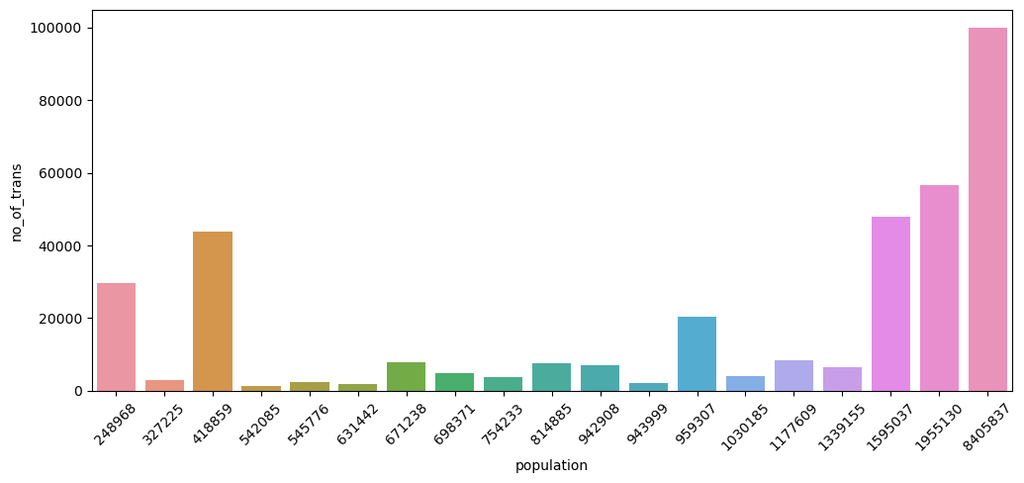

```python
plt.figure(figsize=(12, 5))
sns.barplot(data=city_p, x='population', y='no_of_trans')
plt.xticks(rotation=45);
```

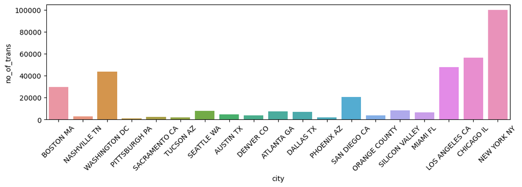

```python
plt.figure(figsize=(12, 3))
sns.barplot(data=city_p.sort_values(by='population'), x='city', y='no_of_trans')
plt.xticks(rotation=45);
```

#### Observations:

- Generally, the number of transactions increase significantly with population for cities with population higher than 1.5 million people.
- There is much difference in the number of transactions for cities with population lower than 1.5 million people
- Except `Washington DC`, `Boston MA` and `San Diego CA` have recorded significantly higher number of transactions than other cities with similar population size

#### Users

```python
df.head()
```

|  | Transaction ID | Date of Travel | Company | City | KM Travelled | Price Charged | Cost of Trip | Population | Users | Customer ID | Payment_Mode | Gender | Age | Income (USD/Month) | Icon | Holiday |
| --- | --- | --- | --- | --- | --- | --- | --- | --- | --- | --- | --- | --- | --- | --- | --- | --- |
| 0 | 10000011 | 2016-01-08 | Pink Cab | ATLANTA GA | 30.45 | 370.95 | 313.63 | 814885 | 24701 | 29290 | Card | Male | 28 | 10813 | rain | No Holiday |
| 1 | 10000012 | 2016-01-06 | Pink Cab | ATLANTA GA | 28.62 | 358.52 | 334.85 | 814885 | 24701 | 27703 | Card | Male | 27 | 9237 | partly-cloudy-day | No Holiday |
| 2 | 10000013 | 2016-01-02 | Pink Cab | ATLANTA GA | 9.04 | 125.20 | 97.63 | 814885 | 24701 | 28712 | Cash | Male | 53 | 11242 | partly-cloudy-day | No Holiday |
| 3 | 10000014 | 2016-01-07 | Pink Cab | ATLANTA GA | 33.17 | 377.40 | 351.60 | 814885 | 24701 | 28020 | Cash | Male | 23 | 23327 | partly-cloudy-day | No Holiday |
| 4 | 10000015 | 2016-01-03 | Pink Cab | ATLANTA GA | 8.73 | 114.62 | 97.78 | 814885 | 24701 | 27182 | Card | Male | 33 | 8536 | partly-cloudy-day | No Holiday |

```python
# Making a dataframe of city users and volume of transaction
city_u = pd.DataFrame({'no_users':df.Users.value_counts(normalize=True).index,
                        'city':df.City.value_counts(normalize=True).index,
                         'no_of_trans':df.Users.value_counts().values,
                        '%age of trans':100*df.Users.value_counts(normalize=True).values})
city_u
```

|  | no_users | city | no_of_trans | %age of trans |
| --- | --- | --- | --- | --- |
| 0 | 302149 | NEW YORK NY | 99885 | 27.79 |
| 1 | 164468 | CHICAGO IL | 56625 | 15.76 |
| 2 | 144132 | LOS ANGELES CA | 48033 | 13.37 |
| 3 | 127001 | WASHINGTON DC | 43737 | 12.17 |
| 4 | 80021 | BOSTON MA | 29692 | 8.26 |
| 5 | 69995 | SAN DIEGO CA | 20488 | 5.70 |
| 6 | 27247 | SILICON VALLEY | 8519 | 2.37 |
| 7 | 25063 | SEATTLE WA | 7997 | 2.23 |
| 8 | 24701 | ATLANTA GA | 7557 | 2.10 |
| 9 | 22157 | DALLAS TX | 7017 | 1.95 |
| 10 | 17675 | MIAMI FL | 6454 | 1.80 |
| 11 | 14978 | AUSTIN TX | 4896 | 1.36 |
| 12 | 12994 | ORANGE COUNTY | 3982 | 1.11 |
| 13 | 12421 | DENVER CO | 3825 | 1.06 |
| 14 | 9270 | NASHVILLE TN | 3010 | 0.84 |
| 15 | 7044 | SACRAMENTO CA | 2367 | 0.66 |
| 16 | 6133 | PHOENIX AZ | 2064 | 0.57 |
| 17 | 5712 | TUCSON AZ | 1931 | 0.54 |
| 18 | 3643 | PITTSBURGH PA | 1313 | 0.37 |

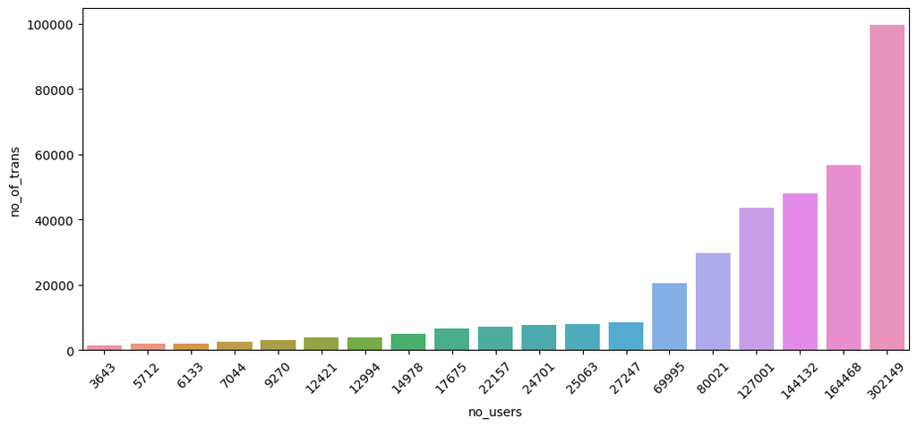

```python
plt.figure(figsize=(12, 5))
sns.barplot(data=city_u, x='no_users', y='no_of_trans')
plt.xticks(rotation=45);
```

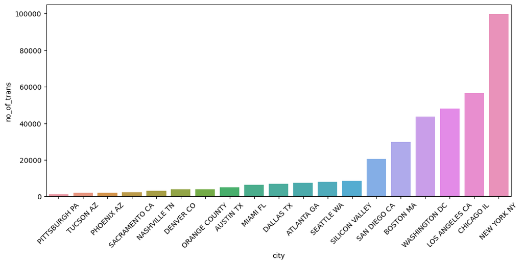

```python
plt.figure(figsize=(12, 5))
sns.barplot(data=city_u.sort_values(by='no_users'), x='city', y='no_of_trans')
plt.xticks(rotation=45);
```

#### Observations:

- As it would be expected, the volume of transactions per city increase with the number of users per city
- Low population cities such as `Washington DC`, `Boston MA` and `San Diego CA` have a significantly higher number of users which explains the high volume of transactions

#### Payment_Mode

```
Card   59.96
Cash   40.04
Name: Payment_Mode, dtype: float64
```

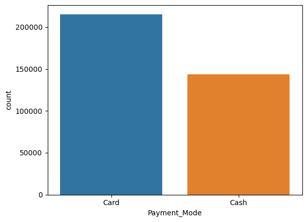

```python
print(df.Payment_Mode.value_counts(normalize=True)*100)
sns.countplot(data=df, x='Payment_Mode');
```

```python
df.Payment_Mode.value_counts(normalize=True)*100
```

```
Card   59.96
Cash   40.04
Name: Payment_Mode, dtype: float64
```

#### Observations:

- There are more transactions completed with card payments than with cash however,
- A significant number of transactions (40% of all transactions or 2 out of every 5 transactions) are settled with cash

#### Gender

```
Male     57.29
Female   42.71
Name: Gender, dtype: float64
```

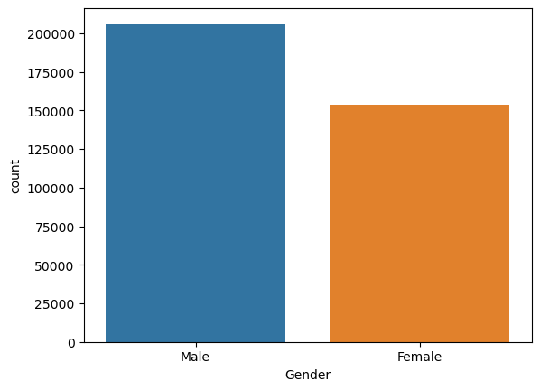

```python
print(df.Gender.value_counts(normalize=True)*100)
sns.countplot(data=df, x='Gender');
```

#### Observations:

- 57% of all users are male while 43% of users are females

#### Age

```python
# Checking the age limits
print(df.Age.min())
df.Age.max()
```

```
18
```

```
65
```

```python
# Making a dataframe of age groups for wasy analysis
age_grp = pd.DataFrame({'age_group': ['below 29', '30-39', '40-49', '50-59', '60 & above'],
                        'vol_transactions': [df[ (df['Age']<30)]['Age'].count(),
                                             df[(df['Age']>=30) & (df['Age']<40)]['Age'].count(),
                                             df[(df['Age']>=40) & (df['Age']<50)]['Age'].count(),
                                             df[(df['Age']>=50) & (df['Age']<60)]['Age'].count(),
                                             df[(df['Age']>=60)]['Age'].count()]})
age_grp
```

|  | age_group | vol_transactions |
| --- | --- | --- |
| 0 | below 29 | 138867 |
| 1 | 30-39 | 112735 |
| 2 | 40-49 | 47017 |
| 3 | 50-59 | 38087 |
| 4 | 60 & above | 22686 |

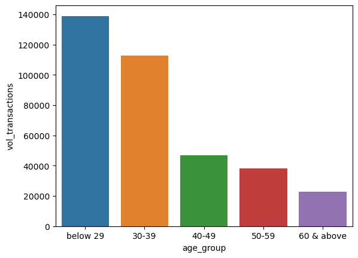

```python
sns.barplot(data=age_grp, x='age_group', y='vol_transactions');
```

#### Observations:

- Generally, younger users tend to conduct more transactions
- The most active age groups are `18-29` and `30-39`

#### Income

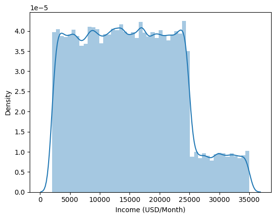

```python
sns.distplot(df['Income (USD/Month)']);
```

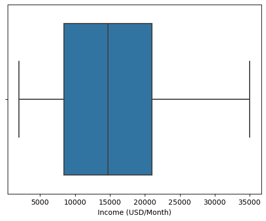

```python
sns.boxplot(data=df, x='Income (USD/Month)');
```

```python
# Checking the lowest and highest income
print(f'The highest income is {df["Income (USD/Month)"].max()} USD')
print(f'The lowest income is {df["Income (USD/Month)"].min()} USD')
```

```
The highest income is 35000 USD
The lowest income is 2000 USD
```

#### Observation:

- The volume of transactions is relatively the same for users with income between 2,000 and about 24,000
- The volume of transactions is relatively the same for users with income between 2,400 and about 35,000
- The volume of transactions for users with income between 2,000 and about 24,000 is at least 4 times more than the volume of transactions for users with income between 2,400 and about 35,000

#### Icon

```
rain                41.16
partly-cloudy-day   37.93
clear-day           15.26
snow                 3.25
cloudy               2.29
wind                 0.10
Name: Icon, dtype: float64
```

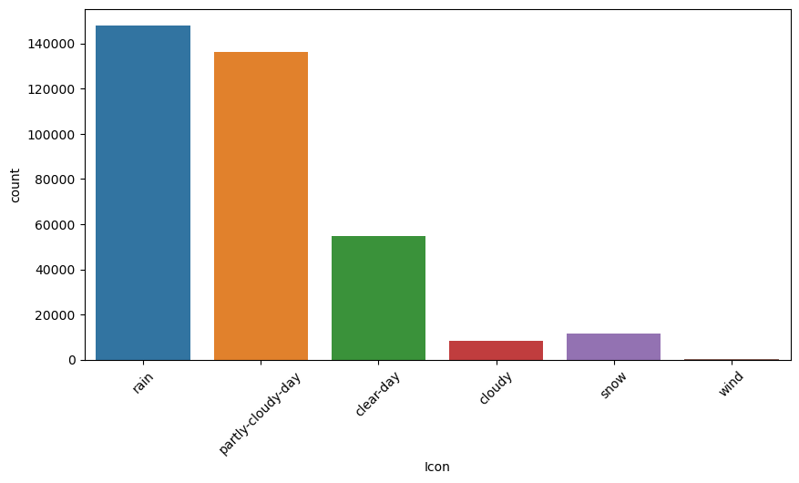

```python
print(df.Icon.value_counts(normalize=True)*100)
plt.figure(figsize=(10, 5))
sns.countplot(data=df, x='Icon')
plt.xticks(rotation=45);
```

#### Observations:

- `rain` is the more common weather condiation occurring on 41% of the total number of days in review
- The next common are `partly-cloudy-day` and `clear-day` occurring on 38% and 15% of the days under review
- These 3 weather types account for 94% of all weather occurrences in the period under review

```python
# Making a dataframe of holidays and their frequency
hol = pd.DataFrame({'holidays':df.Holiday.value_counts(normalize=True).index,
                         'no_of_days':df.Holiday.value_counts().values,
                        })
hol = hol.drop(0)
hol
```

|  | holidays | no_of_days |
| --- | --- | --- |
| 1 | Thanksgiving (Day After) | 2396 |
| 2 | Christmas Eve | 2011 |
| 3 | New Year's Eve | 1780 |
| 4 | Christmas day | 1329 |
| 5 | New Year's Day | 1260 |
| 6 | Thanksgiving | 1166 |
| 7 | Veterans Day | 1012 |
| 8 | Juneteenth National Independence | 747 |
| 9 | Labor Day | 666 |
| 10 | Columbus Day | 459 |
| 11 | Memorial Day | 449 |
| 12 | Independence Day | 447 |
| 13 | President's Day | 343 |
| 14 | Martin Luther King Jr. Day | 325 |
| 15 | Election Day | 219 |
| 16 | Lincoln's Birthday | 186 |
| 17 | Lincoln's Birthday | 133 |
| 18 | César Chávez Day | 98 |
| 19 | Pulaski Day | 63 |
| 20 | Patriots' Day | 42 |
| 21 | Christmas day (Day After) | 23 |
| 22 | Good Friday | 15 |
| 23 | Confederate Memorial Day | 11 |

```python
hol['%age_of_ days'] = hol['no_of_days'] / hol['no_of_days'].sum() * 100
hol
```

|  | holidays | no_of_days | %age_of_ days |
| --- | --- | --- | --- |
| 1 | Thanksgiving (Day After) | 2396 | 15.78 |
| 2 | Christmas Eve | 2011 | 13.25 |
| 3 | New Year's Eve | 1780 | 11.73 |
| 4 | Christmas day | 1329 | 8.75 |
| 5 | New Year's Day | 1260 | 8.30 |
| 6 | Thanksgiving | 1166 | 7.68 |
| 7 | Veterans Day | 1012 | 6.67 |
| 8 | Juneteenth National Independence | 747 | 4.92 |
| 9 | Labor Day | 666 | 4.39 |
| 10 | Columbus Day | 459 | 3.02 |
| 11 | Memorial Day | 449 | 2.96 |
| 12 | Independence Day | 447 | 2.94 |
| 13 | President's Day | 343 | 2.26 |
| 14 | Martin Luther King Jr. Day | 325 | 2.14 |
| 15 | Election Day | 219 | 1.44 |
| 16 | Lincoln's Birthday | 186 | 1.23 |
| 17 | Lincoln's Birthday | 133 | 0.88 |
| 18 | César Chávez Day | 98 | 0.65 |
| 19 | Pulaski Day | 63 | 0.42 |
| 20 | Patriots' Day | 42 | 0.28 |
| 21 | Christmas day (Day After) | 23 | 0.15 |
| 22 | Good Friday | 15 | 0.10 |
| 23 | Confederate Memorial Day | 11 | 0.07 |

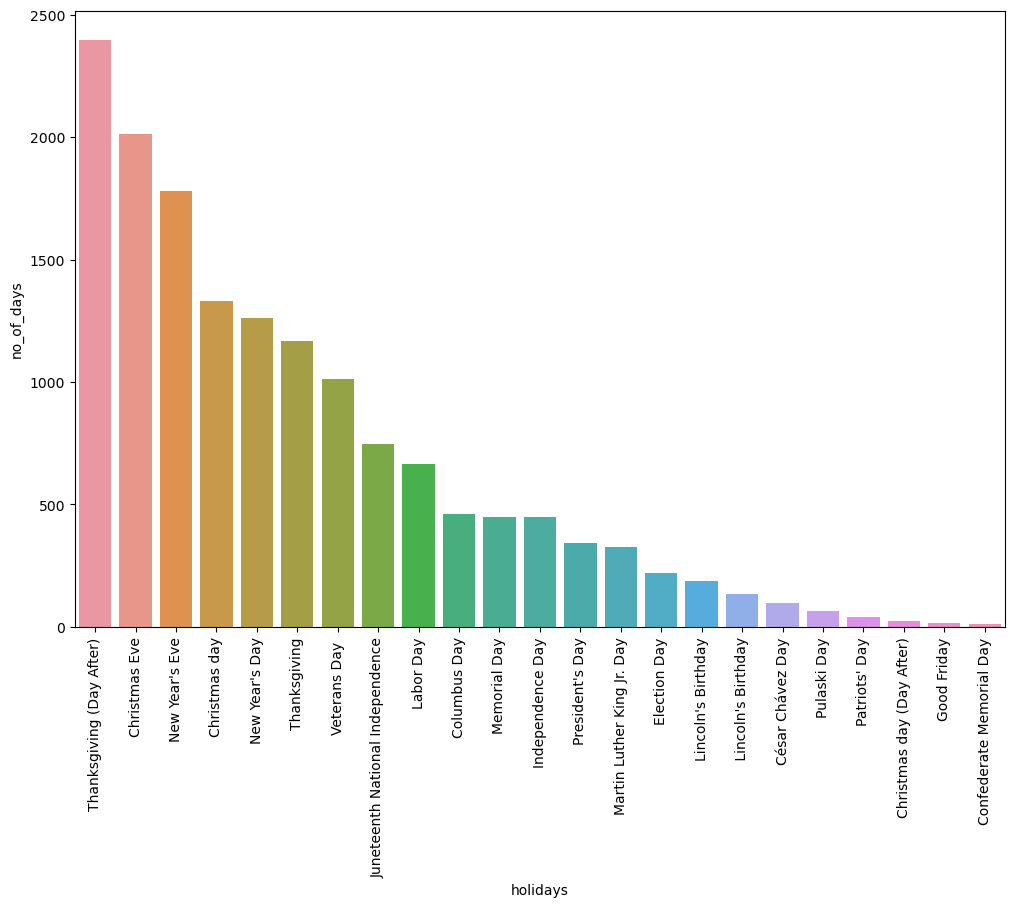

```python
plt.figure(figsize=(12, 8))
sns.barplot(data=hol, x='holidays', y='no_of_days');
plt.xticks(rotation=90);
```

### Multivariate Analysis

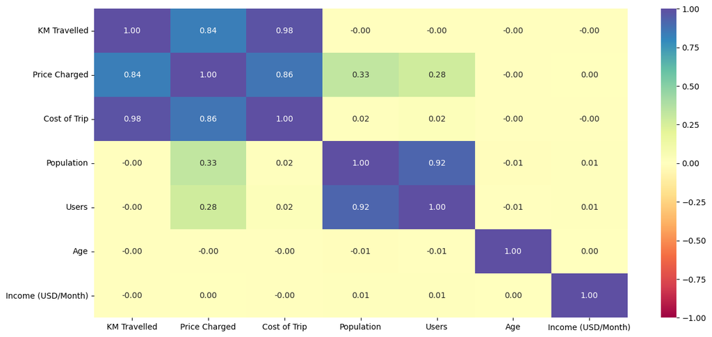

```python
cols_list = df.select_dtypes(include=np.number).columns.tolist()
# dropping Transaction ID and Customer ID as they are unique identifiers
cols_list.remove( "Transaction ID")
cols_list.remove("Customer ID")

plt.figure(figsize=(15, 7))
sns.heatmap(
    df[cols_list].corr(), annot=True, vmin=-1, vmax=1, fmt=".2f", cmap="Spectral"
)
plt.show()
```

#### Observations:

- `KM Travelled` correlates positively and strongly with `Price Charged` and `Cost of Trip`
- `Population` and `Users` are also strongly positively correlated
- `Population` and `Users` are positively correlated with `Price Charged` but not `Cost of Trip`
- There are virtually no other correlations

### Feature Engineering with Bivariate Analysis

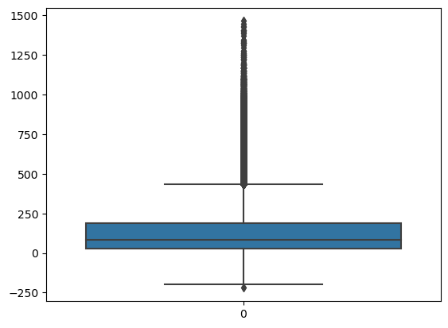

```python
# Creating the Profit column
xf = df.copy()
xf['Profit'] = xf['Price Charged']-xf['Cost of Trip']
sns.boxplot(xf['Profit'])
```

```python
# Calculating the highest loss

print('Observation:')
print(f'The highest loss is {round(xf["Profit"].min(),2)}USD')

# Calculating the number transactions with losses

print(f'The number of transactions with losses are {xf[xf["Profit"]<0]["Profit"].count()} which is {round((xf[xf["Profit"]<0]["Profit"].count()*100)/(xf["Profit"].shape[0]),2)}% of all transactions')
print('There are more transactions with profit many of which appear to outliers and will examined later')
```

```
Observation:
The highest loss is -220.06USD
The number of transactions with losses are 24819 which is 6.91% of all transactions
There are more transactions with profit many of which appear to outliers and will examined later
```

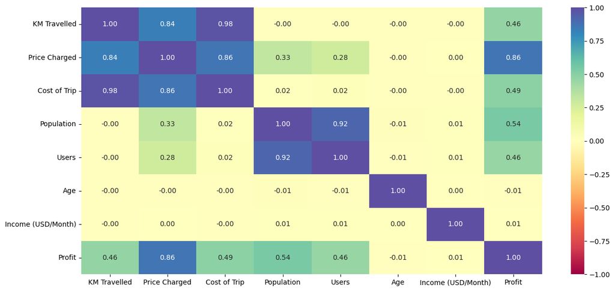

```python
# Correlation plot of numerical variable

cols_list = xf.select_dtypes(include=np.number).columns.tolist()
# dropping Transaction ID and Customer ID as they are unique identifiers
cols_list.remove( "Transaction ID")
cols_list.remove("Customer ID")

plt.figure(figsize=(15, 7))
sns.heatmap(
    xf[cols_list].corr(), annot=True, vmin=-1, vmax=1, fmt=".2f", cmap="Spectral"
)
plt.show()
```

#### Observations:

- In addition to the earlier mentioned correlations new correlations have emerged
- As expected, `Profit` is positively correlated with `KM Travelled`, `Price Charged` and `Cost of Trip`
- Also positively correlated is `Profit` with `Population` and `Users`
- The strength of correlation of `Profit` with other features is in the order `Price Charged`, `Population`, `Cost of Trip`, `KM Travelled` and `Users`
- `Age` and `Income(USD\Month)` do not correlate with any other feature or with each other. They appear not to have any influence on the profits, revenue and costs involved in the cab industry

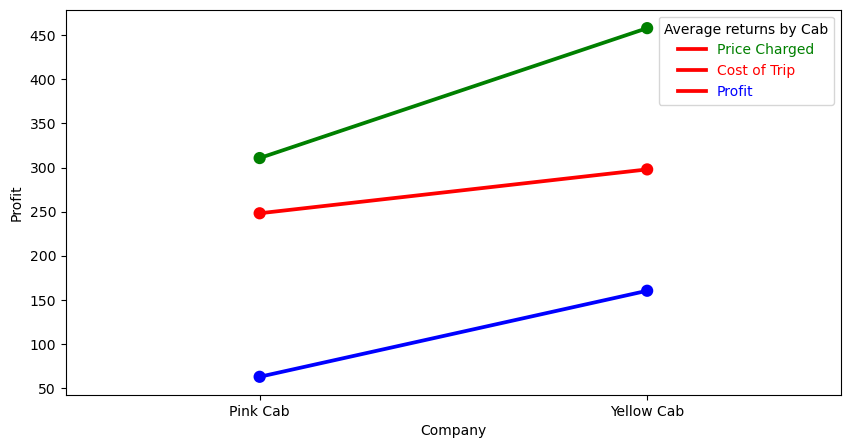

```python
# Average cost, price and profit by company

plt.figure(figsize=(10,5));

sns.pointplot(data=xf, x='Company', y='Cost of Trip', color='red')

sns.pointplot(data=xf, x='Company', y='Price Charged', color='green')

sns.pointplot(data=xf, x='Company', y='Profit', color='blue')

plt.legend(loc='best', title='Average returns by Cab', labels=['Price Charged', 'Cost of Trip', 'Profit'],
           labelcolor=['green', 'red', 'blue'])

plt.show();
```

#### Observations:

- The average `Price Charged`, `Cost of Trip` and `Profit` for the Yellow cab company is higher than Pink cab company

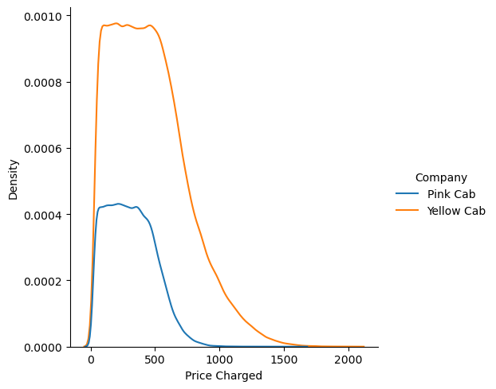

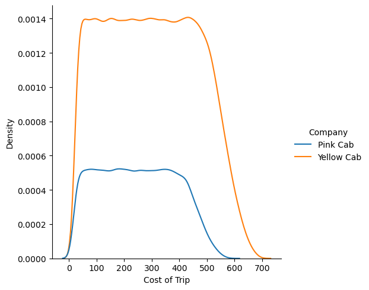

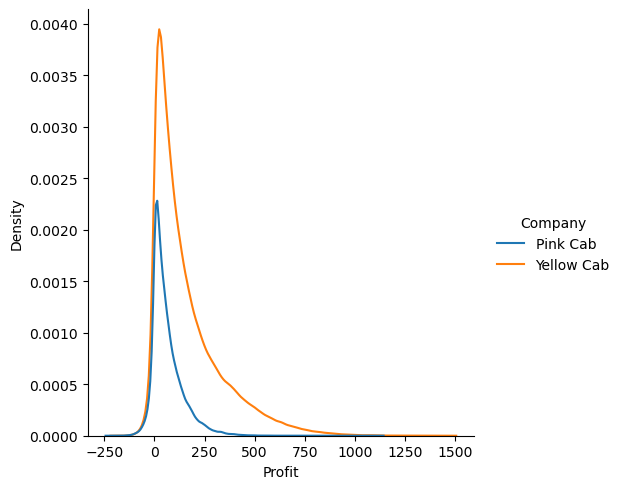

```python
# Distribution analysis with hue
plt.figure(figsize=(10,5));

sns.displot(data=xf,x='Price Charged', kind='kde', hue='Company')

sns.displot(data=xf,x='Cost of Trip', kind='kde', hue='Company')

sns.displot(data=xf,x='Profit', kind='kde', hue='Company')

plt.show();
```

#### Observations:

- The plots show that there is more variability in `Profit`, `Price Charged` and `Cost of Trip` for Yellow cab than Pink cab
- Also observable from the plots is that there more Yellow cabs with higher `Profit`, `Price Charged` and `Cost of Trip` than Pink cabs. The difference is more pronounced in `Price Charged` and `Cost of Trip` than `Profit`

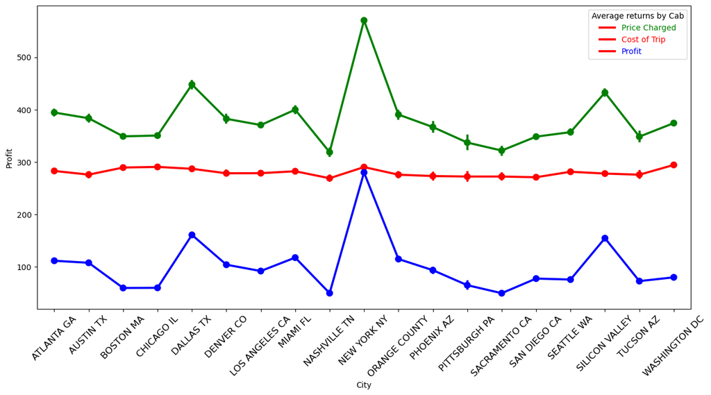

```python
# Average cost, price and profit by city

plt.figure(figsize=(15,7));

sns.pointplot(data=xf, x='City', y='Cost of Trip', color='red')

sns.pointplot(data=xf, x='City', y='Price Charged', color='green')

sns.pointplot(data=xf, x='City', y='Profit', color='blue')

plt.legend(loc='best', title='Average returns by Cab', labels=['Price Charged', 'Cost of Trip', 'Profit'],
           labelcolor=['green', 'red', 'blue'])

plt.xticks(rotation=45, fontsize=12)

plt.show();
```

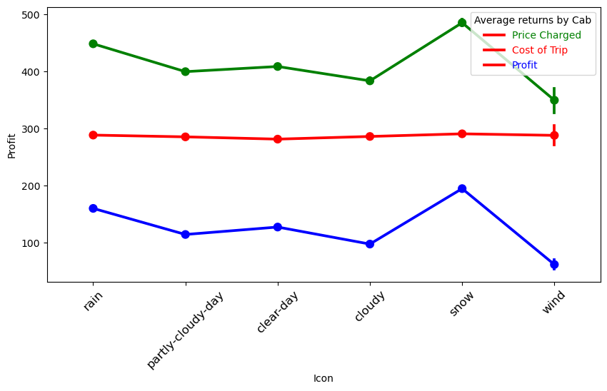

```python
# Average cost, price and profit by Icon

plt.figure(figsize=(10,5));

sns.pointplot(data=xf, x='Icon', y='Cost of Trip', color='red')

sns.pointplot(data=xf, x='Icon', y='Price Charged', color='green')

sns.pointplot(data=xf, x='Icon', y='Profit', color='blue')

plt.legend(loc='best', title='Average returns by Cab', labels=['Price Charged', 'Cost of Trip', 'Profit'],
           labelcolor=['green', 'red', 'blue'])

plt.xticks(rotation=45, fontsize=12)

plt.show();
```

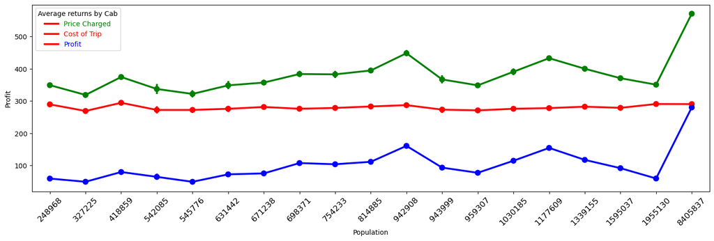

```python
# Average cost, price and profit by Population

plt.figure(figsize=(18,5));

sns.pointplot(data=xf, x='Population', y='Cost of Trip', color='red')

sns.pointplot(data=xf, x='Population', y='Price Charged', color='green')

sns.pointplot(data=xf, x='Population', y='Profit', color='blue')

plt.legend(loc='best', title='Average returns by Cab', labels=['Price Charged', 'Cost of Trip', 'Profit'],
           labelcolor=['green', 'red', 'blue'])

plt.xticks(rotation=45, fontsize=12)

plt.show();
```